# Practica 3

Murillo Alba Josué Iván

Septiembre 2024

```r
library(dplyr)
```

# 1

1. Considera el comportamiento de la mortalidad infantil (MI) en relacion con el PIB per capita (PIBpc).

MI = mortalidad infantil, el numero de defunciones de ninos menores de 5 anos en un ano por cada 1 000 nacidos vivos. PIBPC = PIB per capita en 1980 (USD)

```r
tabla<- read.csv("Practica3.csv")
head(tabla)
```

```
##   Obs  MI TAM PIBPC  TFT
## 1   1 128  37  1870 6.66
## 2   2 204  22   130 6.15
## 3   3 202  16   310 7.00
## 4   4 197  65   570 6.25
## 5   5  96  76  2050 3.81
## 6   6 209  26   200 6.44
```

## (a)

Pide a R el resumen de los estimadores del modelo de regresion lineal. Escribe los estimadores βˆ1 y βˆ2 para el modelo MIi = β1 + β2 PIBpci + ui

```r
tabla0<-select(tabla, MI, PIBPC)
tabla1<- rename(tabla0, Y=MI, X1=PIBPC)
head(tabla1)
```

```
##     Y   X1
## 1 128 1870
## 2 204  130
## 3 202  310
## 4 197  570
## 5  96 2050
## 6 209  200
```

```r
modelo <- lm(Y ~ X1, data = tabla1)
resumen <- summary(modelo)
resumen
```

```
##
## Call:
## lm(formula = Y ~ X1, data = tabla1)
##
## Residuals:
##      Min       1Q   Median       3Q      Max
## -113.764  -53.111   -6.685   48.064  157.758
##
## Coefficients:
##               Estimate Std. Error t value Pr(>|t|)
## (Intercept) 157.424441   9.845583  15.989  < 2e-16 ***
## X1           -0.011364   0.003233  -3.516 0.000826 ***
## ---
## Signif. codes:  0 '***' 0.001 '**' 0.01 '*' 0.05 '.' 0.1 ' ' 1
##
## Residual standard error: 69.93 on 62 degrees of freedom
## Multiple R-squared:  0.1662, Adjusted R-squared:  0.1528
## F-statistic: 12.36 on 1 and 62 DF,  p-value: 0.0008262
```

Los estimadores son B1= 157.42 y B2= -0.011364

```r
B1<- 157.42
B2<- -0.011364
```

## (b)

Interpreta los estimadores.

Ahora nuestra función de regresión puede entenderse como MI= 157.42 -0.011364PIBPCi+ui, si dejamos todo lo demas constante en B2 cada unidad de dolar que se agregue al PIB per capita en 1980 en promedio disminuira el numero de defunciones de ninos menores de 5 anos en un ano por cada 1 000 nacidos vivos en promedio de 0.011364 lo cual tiene sentido ya que si se agrega un dolar a la  
renta de un habitante aumentamos su calidad de vida del padre por tanto mas sano. B1 que es el estimador de intercepto podriamos decir que si hacemos 0 la variable explicativa, el numero de defunciones de ninos menores de 5 anos en un ano por cada 1 000 nacidos seria aproximadamente de 157.42 niños menores de 4 años, aunque debe de tenerse cuidado con esta interpretación ya que si PIBPC=0 claramente aumentaria en gran medida el intercepto hablando en terminos logicos

## (c)

Calcula los intervalos de confianza para los estimadores, con una confianza del 90%, usando las siguientes formulas, βˆ1 − tα/2e.e.(βˆ1) ≤ β1 ≤ βˆ1 + tα/2e.e.(βˆ1)

βˆ2 − tα/2e.e.(βˆ2) ≤ β2 ≤ βˆ2 + tα/2e.e.(βˆ2)

donde t es la distribucion t con n − 2 grados de libertad.

```r
n <- length(tabla1$Y)
gl<- n-2
significancia<- .1
eeB1<- 9.845583
eeB2<- 0.003233

Area <- 1-(significancia/2)
Vqt <- qt(Area,gl)

# Para B1
Intervalo_confianza_B1n <- B1-eeB1*Vqt
Intervalo_confianza_B1n
```

```
## [1] 140.9798
```

```r
Intervalo_confianza_B1p <- B1+eeB1*Vqt
Intervalo_confianza_B1p
```

```
## [1] 173.8602
```

```r
# Para B2

Intervalo_confianza_B2n <- B2-eeB2*Vqt
Intervalo_confianza_B2n
```

```
## [1] -0.01676248
```

```r
Intervalo_confianza_B2p <- B2+eeB2*Vqt
Intervalo_confianza_B2p
```

```
## [1] -0.005965523
```

Compara tus resultados con los intervalos de confianza que calcula R, usando la funcion confint().

```r
Intervalos_confianza <- confint(modelo, level = .90)
Intervalos_confianza
```

```
##                      5 %          95 %
## (Intercept) 140.98424509 173.864636063
## X1           -0.01676213  -0.005966774
```

## (d)

Realiza el diagrama de dispersion, con la lınea de regresion.

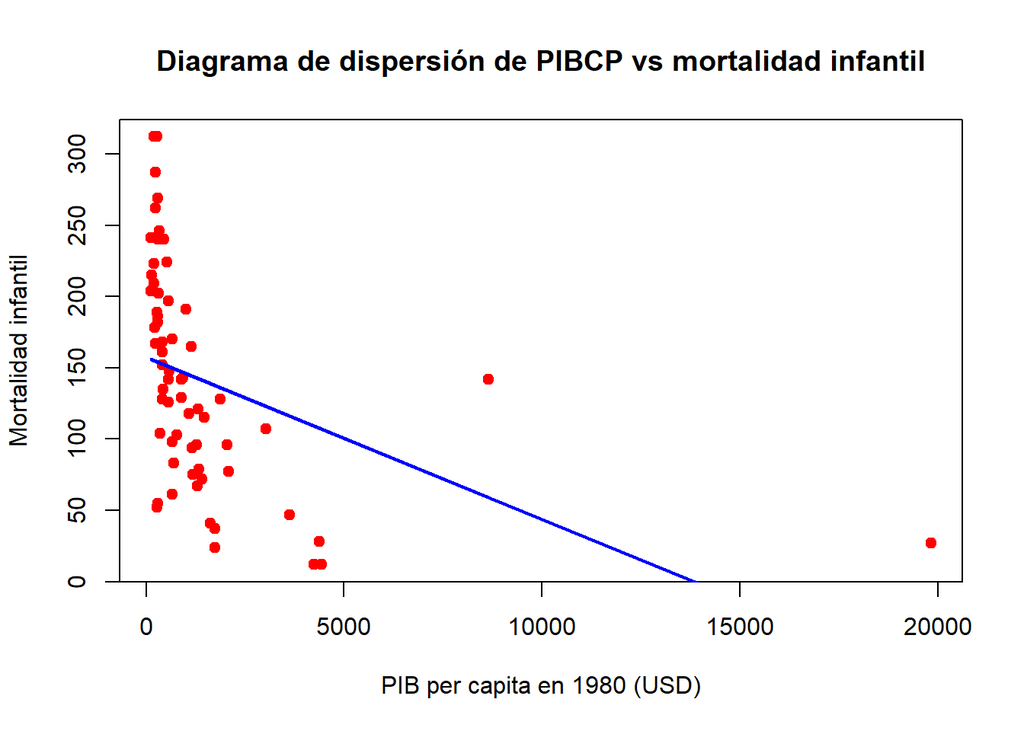

```r
# Generar el gráfico de dispersión
plot(tabla1$X1, tabla1$Y,
     xlab = "PIB per capita en 1980 (USD)",
     ylab = "Mortalidad infantil",
     main = "Diagrama de dispersión de PIBCP vs mortalidad infantil",
     pch=19, col="red")


graficar_funcion <- function(B1, B2, X) {
  Y <- B1 + B2 * X
  lines(X, Y, type="l", col="blue", lwd=2)
}

X <- tabla1$X1
graficar_funcion(B1, B2, X)  # Llamar a la función con B1 y B2 definidos
```

## (e)

Determina si el PIBpc ejerce un impacto negativo o positivo sobre la MI. Da una explicaci´on de por qu´e era de esperarse este resultado.

Si tiene un impacto negativo PIBPC sobre MI, puesto que cuanto mayor sea la calidad de vida de una persona mucha mas salud y mejores condiciones opitimas tendra para procrear, asi el niño nacera fuerte y sano reduciendo asi la tasa de mortalidad infantil

## (f)

Escribe el coeficiente de determinacion R2 del modelo.

```r
R<- 0.1662
```

El valor de R2 es aproximadamente 0.17 significa que casi 17% de la variación en la mortalidad infantil se explica mediante el PIBPC, lo cual es un porcentaje pequeño si se considera que el valor máximo que puede tener R2 es 1.

# 2

Considera ahora tambien como variable independiente, el alfabetismo femenino, medido por la tasa de alfabetizacion de las mujeres (TAM). A priori, se espera que la TAM tambien ejerza un impacto negativo en la MI. Cuando se introducen ambas variables en el modelo, el modelo es: MIi = β1 + β2 *PIBpci + β3*TAMi + ui

Ten en cuenta que la MI es el numero de muertes de ninos menores de 5 anos por cada 1 000 nacidos vivos, el PIBPC es el PIB per capita en 1980 (USD) y la TAM se mide en porcentaje. La muestra se realizo en 64 paıses.

## (a)

Pide a R el resumen de los estimadores del modelo de regresion lineal. Comenta si los signos de los estimadores de los coeficientes son los esperados.

```r
tabla00<-select(tabla, MI, TAM, PIBPC)
tabla2<- rename(tabla00, Y=MI, X1=PIBPC, X2=TAM)
head(tabla2)
```

```
##     Y X2   X1
## 1 128 37 1870
## 2 204 22  130
## 3 202 16  310
## 4 197 65  570
## 5  96 76 2050
## 6 209 26  200
```

```r
modelo2 <- lm(Y ~ X1 + X2, data = tabla2)
summary(modelo2)
```

```
##
## Call:
## lm(formula = Y ~ X1 + X2, data = tabla2)
##
## Residuals:
##     Min      1Q  Median      3Q     Max
## -84.267 -24.363   0.709  19.455  96.803
##
## Coefficients:
##               Estimate Std. Error t value Pr(>|t|)
## (Intercept) 263.641586  11.593179  22.741  < 2e-16 ***
## X1           -0.005647   0.002003  -2.819  0.00649 **
## X2           -2.231586   0.209947 -10.629 1.64e-15 ***
## ---
## Signif. codes:  0 '***' 0.001 '**' 0.01 '*' 0.05 '.' 0.1 ' ' 1
##
## Residual standard error: 41.75 on 61 degrees of freedom
## Multiple R-squared:  0.7077, Adjusted R-squared:  0.6981
## F-statistic: 73.83 on 2 and 61 DF,  p-value: < 2.2e-16
```

Los estimadores para B2 y B3 calculados en este nuevo modelo son negativos como se esperaba que ejerciera un impacto negativo en MI

## (b)

Escribe los estimadores num´ericos de βˆ1, βˆ2, βˆ3 para el modelo.

```r
B1.<-263.641586
B2.<--0.005647
B3.<--2.231586
```

## (c)

Interpreta los valores numericos de los estimadores de acuerdo a este modelo.

El modelo nos dice que que por cada aumento en una unidad de USD el numero de muertes de ninos menores de 5 anos por cada 1 000 nacidos vivos se reduce en promedio en una proporcion de 0.005647 (B2) dejando constante los demas terminos, por cada punto porcentual que aumente la alfabetización de la mujer MI disminuye en promedio en una proporción de 2.231586 (B3) si se dejan constante los demas terminos, para B1 el numero nos dice que si los valores de las variables explicativas son 0 MI sera alrededor de 264

## (d)

Manteniendo constante PIBpc, ¿cuanto tendrıa que aumentar TAM para tener una reduccion de una muerte de un nino menor de 5 anos por cada 1 000 nacidos vivos predichos?

```r
tasa_cambio_MI<--1
tasa_cambio_TAM<-tasa_cambio_MI/B3.
tasa_cambio_TAM
```

```
## [1] 0.4481118
```

## (e)

Para un paıs que tiene un PIB per capita de 680 USD, y una tasa de alfabetizacion de mujeres del 54% ¿Cuanto predice el modelo que, en promedio, serıa el numero de muertes de ninos menores de 5 a˜nos por cada 1 000 nacidos vivos?

```r
PIB_eJem<-680
TAM_ejem<-54
MI_ejem<-B1.+B2.*PIB_eJem+B3.*TAM_ejem
```

## (f)

Suponga que un paıs A tiene un PIB per capita de 3870 USD, y una tasa de alfabetizacion de mujeres del 84%. Por otro lado, un paıs B tiene un PIB per capita de 1100 USD, y una tasa de alfabetizacion de mujeres del 65% ¿Cual es la diferencia entre B y A en muertes de ninos menores de 5 anos por cada 1 000 nacidos vivos?

```r
#pais A
PIB_A<-3870
TAM_A<-84
MI_A<-B1.+B2.*PIB_A+B3.*TAM_A
# pais B
PIB_B<-1100
TAM_B<-65
MI_B<-B1.+B2.*PIB_B+B3.*TAM_B

DIF_MI<-MI_B-MI_A
```

## (g)

Escribe el error estandar para cada estimador

```r
ee2_B1<-11.593179
ee2_B2<-0.002003
ee2_B3<-0.209947
```

## (h)

Escribe el coeficiente de determinacion R2 y el coeficiente ajustado R2adj .

```r
R2_modelo2<-0.7077
R2adj_modelo2<-0.6981
```

Calcula R2 adj a partir del valor de R2, con la formula vista en clase.

```r
#calculo de u^2i estimada
u_estimada<- (tabla2$Y-B1.-B2.*tabla2$X1-B3.*tabla2$X2)
u2_estimada<-(u_estimada)^(2)
sum_u2<-sum(u2_estimada)

x1<-(tabla2$X1-mean(tabla2$X1))
x2<-(tabla2$X2-mean(tabla2$X2))

yi<-B2.*x1+B3.*x2+u_estimada
sum_yi2<-sum(yi^(2))

R2<-1-(sum_u2/sum_yi2)
R2
```

```
## [1] 0.7076655
```

```r
k<-3

R2adj<-1-((sum_u2)*(n-1))/((sum_yi2)*(n-k))
R2adj
```

```
## [1] 0.6980808
```

## i)

Calcula los intervalos de confianza para los estimadores con una confianza del 95%, usando las siguientes formulas, βˆ1 − tα/2e.e.(βˆ1) ≤ β1 ≤ βˆ1 + tα/2e.e.(βˆ1) βˆ2 − tα/2e.e.(βˆ2) ≤ β2 ≤ βˆ2 + tα/2e.e.(βˆ2) βˆ3 − tα/2e.e.(βˆ3) ≤ β3 ≤ βˆ3 + tα/2e.e.(βˆ3)

donde t es la distribucion t con n − 3 grados de libertad. Compara tus resultados con los intervalos de confianza que calcula R, usando la funcion conf int()

```r
gl3<- n-3
significancia95<- .05

Area. <- 1-(significancia95/2)
Vqt. <- qt(Area.,gl3)

# Para B1
InConB1n <- B1.-ee2_B1*Vqt.
InConB1n
```

```
## [1] 240.4596
```

```r
InConB1p <- B1.+ee2_B1*Vqt.
InConB1p
```

```
## [1] 286.8236
```

```r
# Para B2

InConB2n <- B2.-ee2_B2*Vqt.
InConB2n
```

```
## [1] -0.009652246
```

```r
InConB2p <- B2.+ee2_B2*Vqt.
InConB2p
```

```
## [1] -0.001641754
```

```r
# Para B3
InConB3n <- B3.-ee2_B3*Vqt.
InConB3n
```

```
## [1] -2.651401
```

```r
InConB3p <- B3.+ee2_B3*Vqt.
InConB3p
```

```
## [1] -1.811771
```

```r
InCon <- confint(modelo2, level = .95)
InCon
```

```
##                     2.5 %        97.5 %
## (Intercept) 240.459590828 286.823580411
## X1           -0.009652361  -0.001640829
## X2           -2.651401129  -1.811770334
```

## (j)

Calcula los intervalos de confianza para los estimadores con una confianza del 90%, usando las siguientes formulas, βˆ1 − tα/2e.e.(βˆ1) ≤ β1 ≤ βˆ1 + tα/2e.e.(βˆ1) βˆ2 − tα/2e.e.(βˆ2) ≤ β2 ≤ βˆ2 + tα/2e.e.(βˆ2) βˆ3 − tα/2e.e.(βˆ3) ≤ β3 ≤ βˆ3 + tα/2e.e.(βˆ3) donde t es la distribucion t con n − 3 grados de libertad. Compara tus resultados con los intervalos de confianza que calcula R

```r
significancia90<- .1

Area90 <- 1-(significancia90/2)
Vqt90 <- qt(Area90,gl3)

# Para B1
InConB1n <- B1.-ee2_B1*Vqt90
InConB1n
```

```
## [1] 244.2784
```

```r
InConB1p <- B1.+ee2_B1*Vqt90
InConB1p
```

```
## [1] 283.0047
```

```r
# Para B2

InConB2n <- B2.-ee2_B2*Vqt90
InConB2n
```

```
## [1] -0.00899245
```

```r
InConB2p <- B2.+ee2_B2*Vqt90
InConB2p
```

```
## [1] -0.00230155
```

```r
# Para B3
InConB3n <- B3.-ee2_B3*Vqt90
InConB3n
```

```
## [1] -2.582244
```

```r
InConB3p <- B3.+ee2_B3*Vqt90
InConB3p
```

```
## [1] -1.880928
```

```r
InCon90 <- confint(modelo2, level = .90)
InCon90
```

```
##                       5 %          95 %
## (Intercept) 244.278431642 283.004739597
## X1           -0.008992479  -0.002300711
## X2           -2.582243656  -1.880927807
```